[figure not shown]

Bachelors Course Results 2016-17 to 2020-21

M.P. Devlin, ARD Systems, Academic Registrar’s Division

15 July 2021

Mathematics (MA) Courses

Bachelors marks and grades

This is a summary of mark and grade outcomes for undergraduate level Mathematics (MA) courses taken by Bachelors

students over the last 5 years, 2016-17 to 2020-21.

Results on undergraduate courses for students on the General Course, Diploma or Masters programmes and Intercollegiate

and Exchange students are not included.

Absence and Incomplete grades, along with the zero marks, are included among the results. Resit results, including those

with capped marks and grades, are excluded.

Grades for LLB students’ on courses taken outside Law are mapped to the BA/BSc classiﬁcation scheme.

Grades for BA/BSc students taking Law courses are mapped to the LLB classiﬁcation scheme appropriate to the course

level.

Plots and Tables

Histograms summarise the Agreed marks from the most recent year for which results exist, illustrating the distribution,

with a bin-width of 2 marks, coloured by grade;

Barcharts present the outcomes in grades. One ﬁlled to show the proportion of results in each grade, the other of counts

in each grade.

Box-plots simplify the distribution into quartiles, boxes mark the inter-quartile range, divided by the median. Notches

around the median indicate the margin of error around the measure, increasing as the number of results fall. Outer

quartiles are covered by lines up to 1.5 times the inter-quartile range, beyond which individual marks are plotted as

outliers.

ecdf (empirical cumulative distribution function) plots indicate the proportion of results up to a given mark, or mark for

a given percentile for 5 years;

The two tables that follow set out summaries of the marks and grades for all results on undergraduate level courses in

each year.

Comments

Any comments or questions are welcome.

Mark Devlin

ARD Systems,

Academic Registrar’s Division

m.p.devlin@lse.ac.uk

1

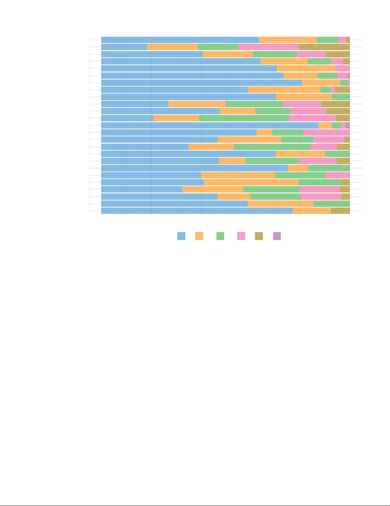

MA334 (n: 13, median: 76)

MA323 (n: 34, median: 72.5)

MA322 (n: 30, median: 65.5)

MA321 (n: 49, median: 65)

MA320 (n: 29, median: 67)

MA319 (n: 30, median: 64.5)

MA318 (n: 12, median: 72.5)

MA317 (n: 19, median: 63)

MA315 (n: 10, median: 82.5)

MA314 (n: 77, median: 61)

MA301 (n: 47, median: 68)

MA300 (n: 16, median: 70)

MA231 (n: 55, median: 88)

MA212 (n: 224, median: 56)

MA211 (n: 21, median: 68)

MA210 (n: 26, median: 59)

MA209 (n: 57, median: 79)

MA208 (n: 51, median: 76)

MA207 (n: 129, median: 80)

MA203 (n: 116, median: 81.5)

MA110 (n: 17, median: 81)

MA107 (n: 528, median: 75)

MA103 (n: 179, median: 63)

MA102 (n: 49, median: 54)

MA100 (n: 651, median: 75)

0% 10% 20% 30% 40% 50% 60% 70% 80% 90% 100%

Grades 1 2A 2B 3 F AB

Bachelors' Course Grades in Mathematics (MA), 2020−21

2

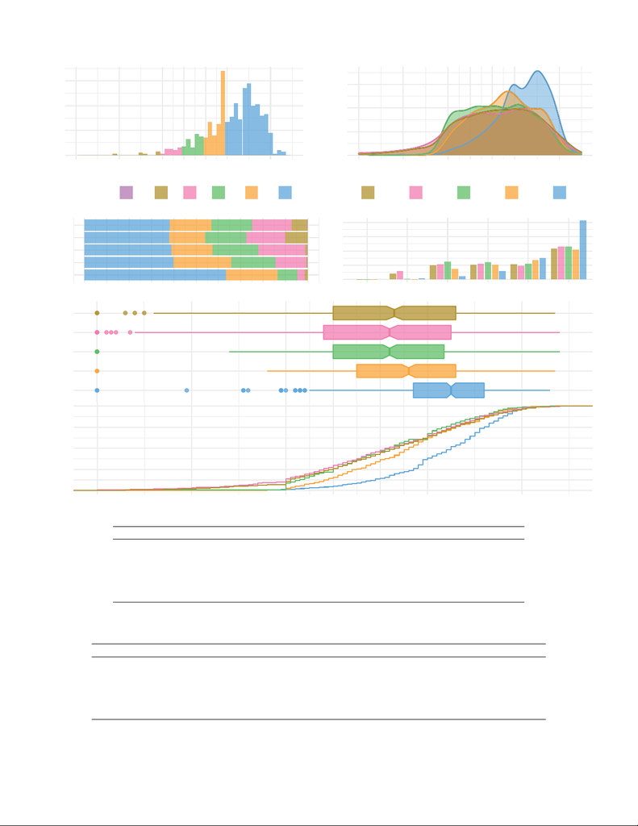

MA100: Mathematical Methods

2020/21

0 20 40 50 60 70 90

0

20

40

60

mark

count

0.0%

1.0%

2.0%

3.0%

0 20 40 50 60 70 90

mark

density

2020/21

2019/20

2018/19

2017/18

2016/17

0% 10% 20% 30% 40% 50% 60% 70% 80% 90% 100%

percent

Grades

AB F 3 2B 2A 1

0

100

200

300

400

AB F 3 2B 2A 1

grade

count

Year

2016/17 2017/18 2018/19 2019/20 2020/21

2020/21

2019/20

2018/19

2017/18

2016/17

0%

25%

50%

75%

100%

0 20 40 50 60 70 90

mark

Year results mean sd min q10 q25 median q75 q90 q95 max

2016/17 571 62.00 18.05 0 40 50 63.00 76 84 89 97

2017/18 607 60.60 18.80 0 40 48 62.00 75 83 87 98

2018/19 595 61.90 15.36 0 42 50 62.00 73 83 85 98

2019/20 523 65.50 13.95 0 47 55 66.00 76 83 86 97

2020/21 651 73.00 12.61 0 57 67 75.00 82 87 89 96

MA100: Mark summary – Mean, Standard deviation and Quantiles.

Year results AB F 3 2B 2A 1 %: AB F 3 2B 2A 1

2016/17 571 1 40 101 104 107 218 0.2 7.0 17.7 18.2 18.7 38.2

2017/18 607 60 107 112 97 231 9.9 17.6 18.5 16.0 38.1

2018/19 595 1 5 125 123 109 232 0.2 0.8 21.0 20.7 18.3 39.0

2019/20 523 1 2 72 104 136 208 0.2 0.4 13.8 19.9 26.0 39.8

2020/21 651 9 21 58 150 413 1.4 3.2 8.9 23.0 63.4

MA100: Grade Summary – Count and Percentage distribution.

3

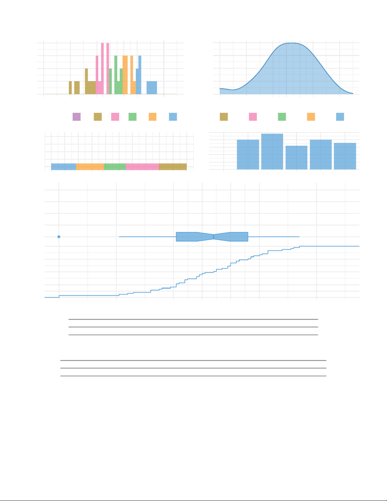

MA102: Mathematical Proof and Analysis

2020/21

0 20 40 50 60 70 90

0

1

2

3

4

mark

count

0.00%

0.50%

1.00%

1.50%

2.00%

0 20 40 50 60 70 90

mark

density

2020/21

2019/20

2018/19

2017/18

2016/17

0% 10% 20% 30% 40% 50% 60% 70% 80% 90% 100%

percent

Grades

AB F 3 2B 2A 1

0.0

2.5

5.0

7.5

10.0

12.5

AB F 3 2B 2A 1

grade

count

Year

2016/17 2017/18 2018/19 2019/20 2020/21

2020/21

2019/20

2018/19

2017/18

2016/17

0%

25%

50%

75%

100%

0 20 40 50 60 70 90

mark

Year results mean sd min q10 q25 median q75 q90 q95 max

2020/21 49 51.90 18.88 0 30 41 54.00 66 73 79 84

MA102: Mark summary – Mean, Standard deviation and Quantiles.

Year results AB F 3 2B 2A 1 %: AB F 3 2B 2A 1

2020/21 49 10 12 8 10 9 20.4 24.5 16.3 20.4 18.4

MA102: Grade Summary – Count and Percentage distribution.

4

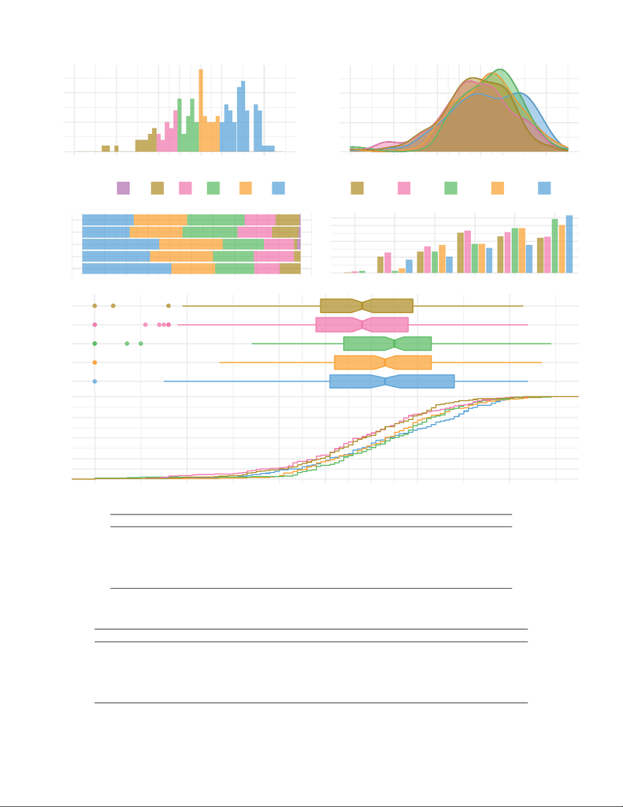

MA103: Introduction to Abstract Mathematics

2020/21

0 20 40 50 60 70 90

0

5

10

mark

count

0.0%

1.0%

2.0%

0 20 40 50 60 70 90

mark

density

2020/21

2019/20

2018/19

2017/18

2016/17

0% 10% 20% 30% 40% 50% 60% 70% 80% 90% 100%

percent

Grades

AB F 3 2B 2A 1

0

20

40

60

AB F 3 2B 2A 1

grade

count

Year

2016/17 2017/18 2018/19 2019/20 2020/21

2020/21

2019/20

2018/19

2017/18

2016/17

0%

25%

50%

75%

100%

0 20 40 50 60 70 90

mark

Year results mean sd min q10 q25 median q75 q90 q95 max

2016/17 192 57.60 15.56 0 37 49 58.00 69 74 79 93

2017/18 214 56.90 17.60 0 33 48 58.00 68 79 83 94

2018/19 196 63.20 15.68 0 46 54 65.00 73 80 84 99

2019/20 197 62.60 15.29 0 44 52 63.00 73 81 85 97

2020/21 179 63.30 17.34 0 40 51 63.00 78 83 88 94

MA103: Mark summary – Mean, Standard deviation and Quantiles.

Year results AB F 3 2B 2A 1 %: AB F 3 2B 2A 1

2016/17 192 1 21 27 51 47 45 0.5 10.9 14.1 26.6 24.5 23.4

2017/18 214 2 26 34 54 52 46 0.9 12.1 15.9 25.2 24.3 21.5

2018/19 196 3 3 27 37 57 69 1.5 1.5 13.8 18.9 29.1 35.2

2019/20 197 6 36 37 57 61 3.0 18.3 18.8 28.9 31.0

2020/21 179 17 21 32 36 73 9.5 11.7 17.9 20.1 40.8

MA103: Grade Summary – Count and Percentage distribution.

5

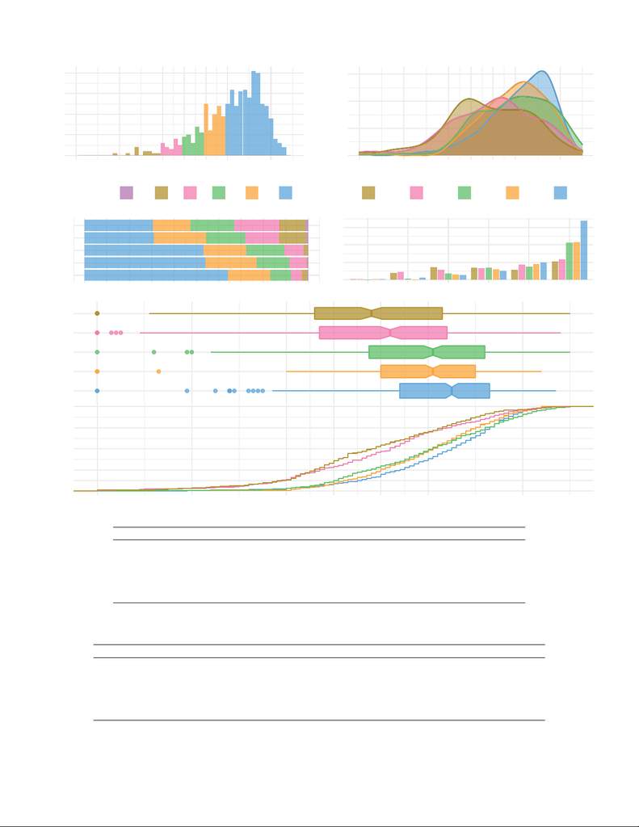

MA107: Quantitative Methods (Mathematics)

2020/21

0 20 40 50 60 70 90

0

10

20

30

40

mark

count

0.0%

1.0%

2.0%

3.0%

0 20 40 50 60 70 90

mark

density

2020/21

2019/20

2018/19

2017/18

2016/17

0% 10% 20% 30% 40% 50% 60% 70% 80% 90% 100%

percent

Grades

AB F 3 2B 2A 1

0

100

200

300

AB F 3 2B 2A 1

grade

count

Year

2016/17 2017/18 2018/19 2019/20 2020/21

2020/21

2019/20

2018/19

2017/18

2016/17

0%

25%

50%

75%

100%

0 20 40 50 60 70 90

mark

Year results mean sd min q10 q25 median q75 q90 q95 max

2016/17 347 58.10 18.85 0 36 46 58.00 73 81 86 100

2017/18 377 60.20 19.31 0 37 47 62.00 74 85 88 98

2018/19 399 69.60 16.31 0 49 57 71.00 82 90 93 100

2019/20 399 69.60 14.28 0 51 60 71.00 80 87 91 94

2020/21 528 72.20 14.73 0 53 64 75.00 83 88 90 97

MA107: Mark summary – Mean, Standard deviation and Quantiles.

Year results AB F 3 2B 2A 1 %: AB F 3 2B 2A 1

2016/17 347 4 40 71 68 58 106 1.2 11.5 20.5 19.6 16.7 30.5

2017/18 377 3 46 57 66 88 117 0.8 12.2 15.1 17.5 23.3 31.0

2018/19 399 1 7 35 68 76 212 0.3 1.8 8.8 17.0 19.0 53.1

2019/20 399 2 1 30 59 91 216 0.5 0.3 7.5 14.8 22.8 54.1

2020/21 528 2 12 26 50 100 338 0.4 2.3 4.9 9.5 18.9 64.0

MA107: Grade Summary – Count and Percentage distribution.

6

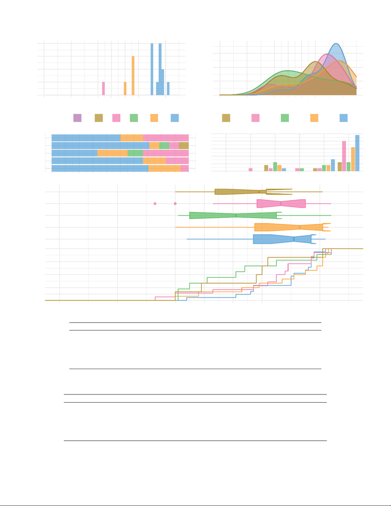

MA110: Basic Quantitative Methods

2020/21

0 20 40 50 60 70 90

0

1

2

3

4

mark

count

0.0%

1.0%

2.0%

3.0%

0 20 40 50 60 70 90

mark

density

2020/21

2019/20

2018/19

2017/18

2016/17

0% 10% 20% 30% 40% 50% 60% 70% 80% 90% 100%

percent

Grades

AB F 3 2B 2A 1

0.0

2.5

5.0

7.5

10.0

12.5

AB F 3 2B 2A 1

grade

count

Year

2016/17 2017/18 2018/19 2019/20 2020/21

2020/21

2019/20

2018/19

2017/18

2016/17

0%

25%

50%

75%

100%

0 20 40 50 60 70 90

mark

Year results mean sd min q10 q25 median q75 q90 q95 max

2016/17 6 65.00 18.11 40 44 53 69.00 71 81 86 91

2017/18 14 71.90 18.13 33 43 68 76.50 85 87 90 94

2018/19 9 62.30 20.06 41 41 45 61.00 75 90 92 94

2019/20 12 76.60 18.00 40 49 67 83.00 91 91 92 93

2020/21 17 78.00 12.76 44 64 67 81.00 87 88 88 92

MA110: Mark summary – Mean, Standard deviation and Quantiles.

Year results AB F 3 2B 2A 1 %: AB F 3 2B 2A 1

2016/17 6 2 1 3 33.3 16.7 50.0

2017/18 14 1 1 1 1 10 7.1 7.1 7.1 7.1 71.4

2018/19 9 3 1 2 3 33.3 11.1 22.2 33.3

2019/20 12 2 2 8 16.7 16.7 66.7

2020/21 17 1 4 12 5.9 23.5 70.6

MA110: Grade Summary – Count and Percentage distribution.

7

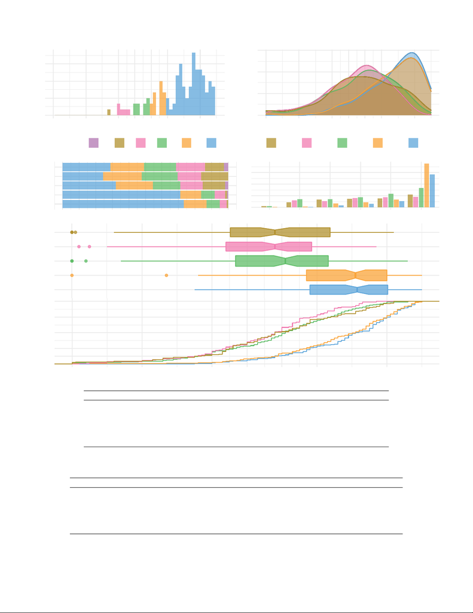

MA203: Real Analysis

2020/21

0 20 40 50 60 70 90

0

3

6

9

mark

count

0.0%

1.0%

2.0%

3.0%

0 20 40 50 60 70 90

mark

density

2020/21

2019/20

2018/19

2017/18

2016/17

0% 10% 20% 30% 40% 50% 60% 70% 80% 90% 100%

percent

Grades

AB F 3 2B 2A 1

0

30

60

90

AB F 3 2B 2A 1

grade

count

Year

2016/17 2017/18 2018/19 2019/20 2020/21

2020/21

2019/20

2018/19

2017/18

2016/17

0%

25%

50%

75%

100%

0 20 40 50 60 70 90

mark

Year results mean sd min q10 q25 median q75 q90 q95 max

2016/17 114 58.20 21.33 0 30 45 58.00 73 84 88 92

2017/18 111 55.40 18.20 2 32 44 58.00 68 76 82 87

2018/19 156 58.80 19.71 0 33 46 61.00 73 82 86 96

2019/20 159 76.70 16.63 0 54 67 81.00 90 95 97 100

2020/21 116 78.60 15.15 35 57 68 81.50 90 95 97 100

MA203: Mark summary – Mean, Standard deviation and Quantiles.

Year results AB F 3 2B 2A 1 %: AB F 3 2B 2A 1

2016/17 114 3 13 20 22 23 33 2.6 11.4 17.5 19.3 20.2 28.9

2017/18 111 18 16 24 26 27 16.2 14.4 21.6 23.4 24.3

2018/19 156 3 21 21 26 35 50 1.9 13.5 13.5 16.7 22.4 32.1

2019/20 159 1 2 10 13 20 113 0.6 1.3 6.3 8.2 12.6 71.1

2020/21 116 1 5 9 16 85 0.9 4.3 7.8 13.8 73.3

MA203: Grade Summary – Count and Percentage distribution.

8

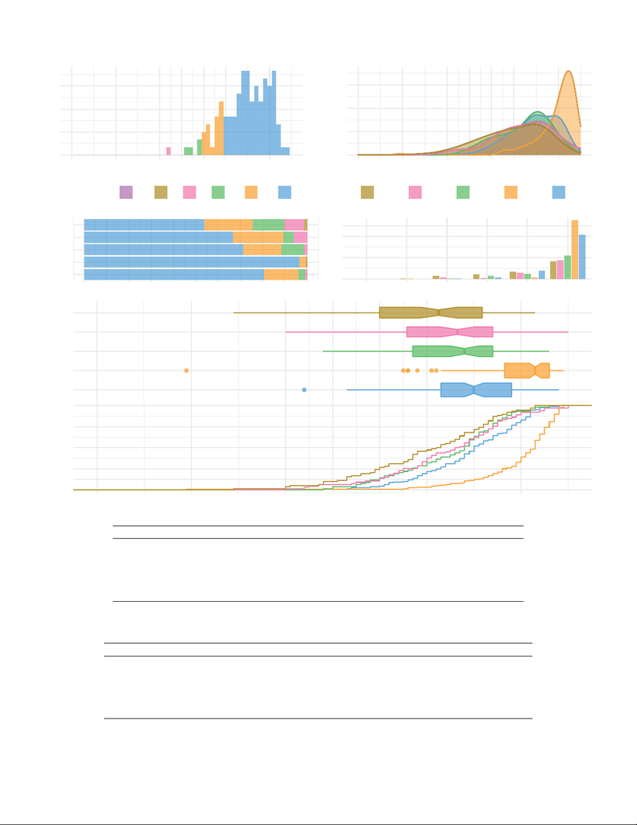

MA207: Further Quantitative Methods (Mathematics)

2020/21

0 20 40 50 60 70 90

0

3

6

9

mark

count

0.0%

2.0%

4.0%

6.0%

0 20 40 50 60 70 90

mark

density

2020/21

2019/20

2018/19

2017/18

2016/17

0% 10% 20% 30% 40% 50% 60% 70% 80% 90% 100%

percent

Grades

AB F 3 2B 2A 1

0

50

100

AB F 3 2B 2A 1

grade

count

Year

2016/17 2017/18 2018/19 2019/20 2020/21

2020/21

2019/20

2018/19

2017/18

2016/17

0%

25%

50%

75%

100%

0 20 40 50 60 70 90

mark

Year results mean sd min q10 q25 median q75 q90 q95 max

2016/17 78 69.90 14.31 29 50 60 72.50 81 86 89 93

2017/18 66 74.60 13.38 40 58 65 76.50 84 89 94 100

2018/19 77 75.10 11.47 48 58 67 78.00 84 88 92 96

2019/20 143 89.70 9.62 19 78 86 93.00 96 97 98 99

2020/21 129 79.40 10.60 44 65 73 80.00 88 92 92 98

MA207: Mark summary – Mean, Standard deviation and Quantiles.

Year results AB F 3 2B 2A 1 %: AB F 3 2B 2A 1

2016/17 78 1 7 11 17 42 1.3 9.0 14.1 21.8 53.8

2017/18 66 4 3 15 44 6.1 4.5 22.7 66.7

2018/19 77 1 8 13 55 1.3 10.4 16.9 71.4

2019/20 143 1 4 138 0.7 2.8 96.5

2020/21 129 1 4 20 104 0.8 3.1 15.5 80.6

MA207: Grade Summary – Count and Percentage distribution.

9

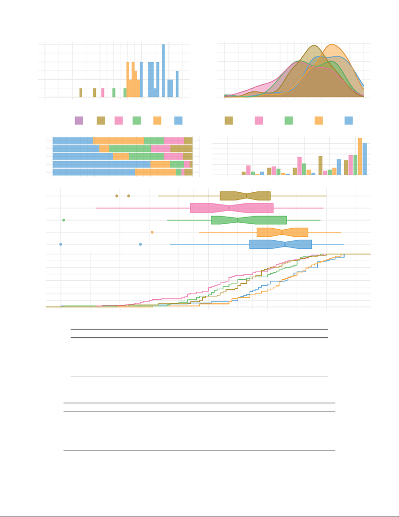

MA208: Optimisation Theory

2020/21

0 20 40 50 60 70 90

0

2

4

6

mark

count

0.0%

1.0%

2.0%

3.0%

0 20 40 50 60 70 90

mark

density

2020/21

2019/20

2018/19

2017/18

2016/17

0% 10% 20% 30% 40% 50% 60% 70% 80% 90% 100%

percent

Grades

AB F 3 2B 2A 1

0

10

20

30

AB F 3 2B 2A 1

grade

count

Year

2016/17 2017/18 2018/19 2019/20 2020/21

2020/21

2019/20

2018/19

2017/18

2016/17

0%

25%

50%

75%

100%

0 20 40 50 60 70 90

mark

Year results mean sd min q10 q25 median q75 q90 q95 max

2016/17 49 62.30 14.99 19 46 54 63.00 71 80 83 90

2017/18 57 56.30 18.77 12 29 44 57.00 72 79 84 89

2018/19 44 61.60 17.33 1 43 51 60.00 76 80 81 88

2019/20 50 74.20 13.52 31 57 66 75.00 83 90 92 95

2020/21 51 71.90 18.15 0 58 64 76.00 85 91 94 96

MA208: Mark summary – Mean, Standard deviation and Quantiles.

Year results AB F 3 2B 2A 1 %: AB F 3 2B 2A 1

2016/17 49 3 7 7 18 14 6.1 14.3 14.3 36.7 28.6

2017/18 57 9 8 17 4 19 15.8 14.0 29.8 7.0 33.3

2018/19 44 3 6 11 5 19 6.8 13.6 25.0 11.4 43.2

2019/20 50 1 2 5 7 35 2.0 4.0 10.0 14.0 70.0

2020/21 51 3 1 2 15 30 5.9 2.0 3.9 29.4 58.8

MA208: Grade Summary – Count and Percentage distribution.

10

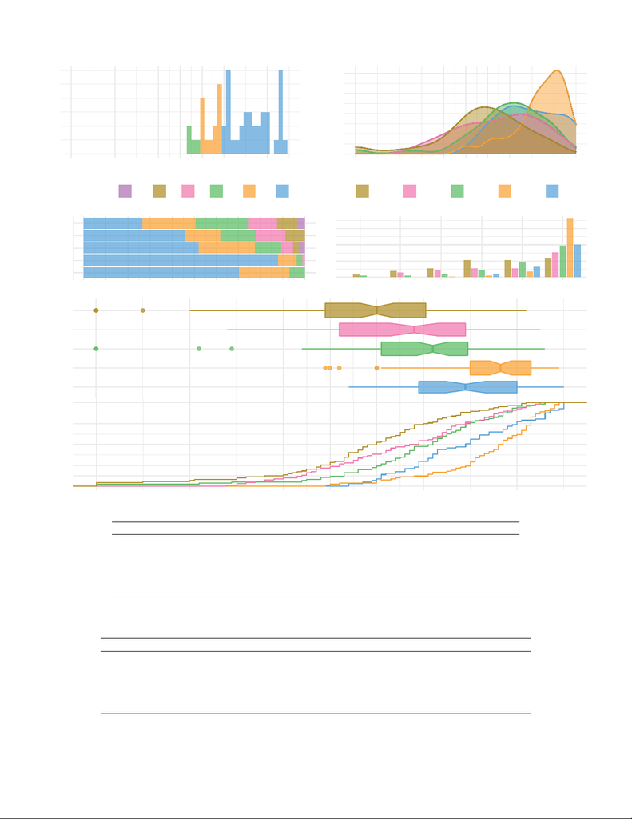

MA209: Differential Equations

2020/21

0 20 40 50 60 70 90

0

2

4

6

mark

count

0.0%

1.0%

2.0%

3.0%

4.0%

0 20 40 50 60 70 90

mark

density

2020/21

2019/20

2018/19

2017/18

2016/17

0% 10% 20% 30% 40% 50% 60% 70% 80% 90% 100%

percent

Grades

AB F 3 2B 2A 1

0

20

40

60

AB F 3 2B 2A 1

grade

count

Year

2016/17 2017/18 2018/19 2019/20 2020/21

2020/21

2019/20

2018/19

2017/18

2016/17

0%

25%

50%

75%

100%

0 20 40 50 60 70 90

mark

Year results mean sd min q10 q25 median q75 q90 q95 max

2016/17 87 57.30 20.61 0 31 49 60.00 70 80 85 92

2017/18 68 65.30 17.70 28 42 52 68.00 79 87 91 95

2018/19 75 68.40 18.52 0 48 61 72.00 79 88 90 96

2019/20 82 83.90 11.76 49 65 80 86.50 93 95 98 99

2020/21 57 78.80 13.56 54 61 69 79.00 90 97 100 100

MA209: Mark summary – Mean, Standard deviation and Quantiles.

Year results AB F 3 2B 2A 1 %: AB F 3 2B 2A 1

2016/17 87 3 8 11 21 21 23 3.4 9.2 12.6 24.1 24.1 26.4

2017/18 68 6 9 11 11 31 8.8 13.2 16.2 16.2 45.6

2018/19 75 2 2 4 9 19 39 2.7 2.7 5.3 12.0 25.3 52.0

2019/20 82 1 2 7 72 1.2 2.4 8.5 87.8

2020/21 57 4 13 40 7.0 22.8 70.2

MA209: Grade Summary – Count and Percentage distribution.

11

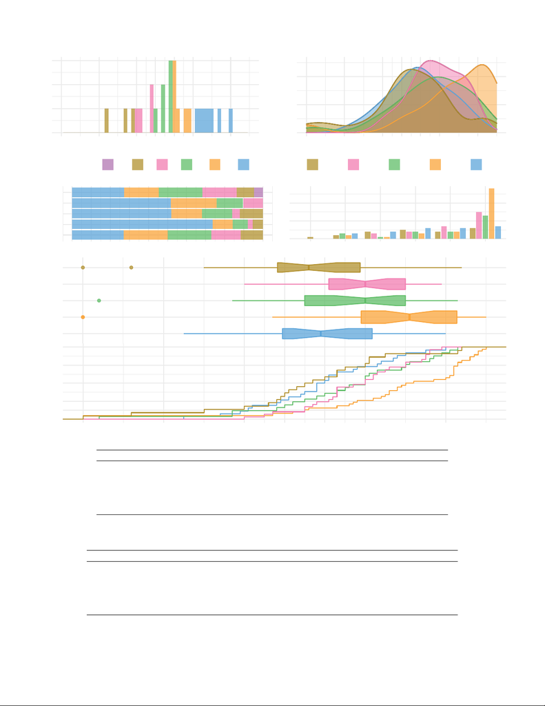

MA210: Discrete Mathematics

2020/21

0 20 40 50 60 70 90

0

1

2

3

mark

count

0.0%

1.0%

2.0%

0 20 40 50 60 70 90

mark

density

2020/21

2019/20

2018/19

2017/18

2016/17

0% 10% 20% 30% 40% 50% 60% 70% 80% 90% 100%

percent

Grades

AB F 3 2B 2A 1

0

10

20

AB F 3 2B 2A 1

grade

count

Year

2016/17 2017/18 2018/19 2019/20 2020/21

2020/21

2019/20

2018/19

2017/18

2016/17

0%

25%

50%

75%

100%

0 20 40 50 60 70 90

mark

Year results mean sd min q10 q25 median q75 q90 q95 max

2016/17 22 55.30 22.14 0 31 48 56.00 68 74 92 94

2017/18 29 68.30 13.21 40 53 61 70.00 80 85 86 89

2018/19 25 65.40 20.37 4 41 55 70.00 80 88 90 93

2019/20 38 77.30 23.42 0 54 69 81.00 92 97 98 100

2020/21 26 59.60 16.09 25 40 49 59.00 71 79 83 90

MA210: Mark summary – Mean, Standard deviation and Quantiles.

Year results AB F 3 2B 2A 1 %: AB F 3 2B 2A 1

2016/17 22 1 2 4 5 4 6 4.5 9.1 18.2 22.7 18.2 27.3

2017/18 29 3 4 7 15 10.3 13.8 24.1 51.7

2018/19 25 3 1 4 4 13 12.0 4.0 16.0 16.0 52.0

2019/20 38 2 1 3 4 28 5.3 2.6 7.9 10.5 73.7

2020/21 26 3 4 6 6 7 11.5 15.4 23.1 23.1 26.9

MA210: Grade Summary – Count and Percentage distribution.

12

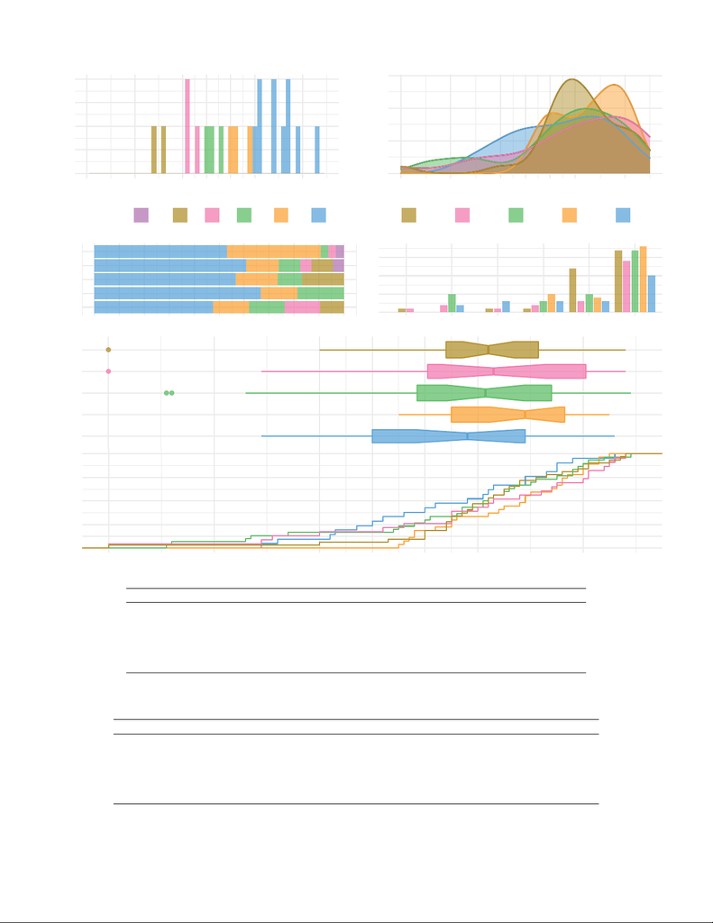

MA211: Algebra and Number Theory

2020/21

0 20 40 50 60 70 90

0.0

0.5

1.0

1.5

2.0

mark

count

0.0%

1.0%

2.0%

3.0%

0 20 40 50 60 70 90

mark

density

2020/21

2019/20

2018/19

2017/18

2016/17

0% 10% 20% 30% 40% 50% 60% 70% 80% 90% 100%

percent

Grades

AB F 3 2B 2A 1

0

5

10

15

AB F 3 2B 2A 1

grade

count

Year

2016/17 2017/18 2018/19 2019/20 2020/21

2020/21

2019/20

2018/19

2017/18

2016/17

0%

25%

50%

75%

100%

0 20 40 50 60 70 90

mark

Year results mean sd min q10 q25 median q75 q90 q95 max

2016/17 32 71.20 18.56 0 60 64 72.00 81 91 95 98

2017/18 23 69.70 25.39 0 32 60 73.00 90 94 95 98

2018/19 30 66.60 23.68 11 26 58 71.50 84 90 92 99

2019/20 27 76.20 13.07 55 57 65 79.00 86 91 93 95

2020/21 21 64.40 19.22 29 42 50 68.00 79 85 88 96

MA211: Mark summary – Mean, Standard deviation and Quantiles.

Year results AB F 3 2B 2A 1 %: AB F 3 2B 2A 1

2016/17 32 1 1 1 12 17 3.1 3.1 3.1 37.5 53.1

2017/18 23 1 2 1 2 3 14 4.3 8.7 4.3 8.7 13.0 60.9

2018/19 30 5 3 5 17 16.7 10.0 16.7 56.7

2019/20 27 5 4 18 18.5 14.8 66.7

2020/21 21 2 3 3 3 10 9.5 14.3 14.3 14.3 47.6

MA211: Grade Summary – Count and Percentage distribution.

13

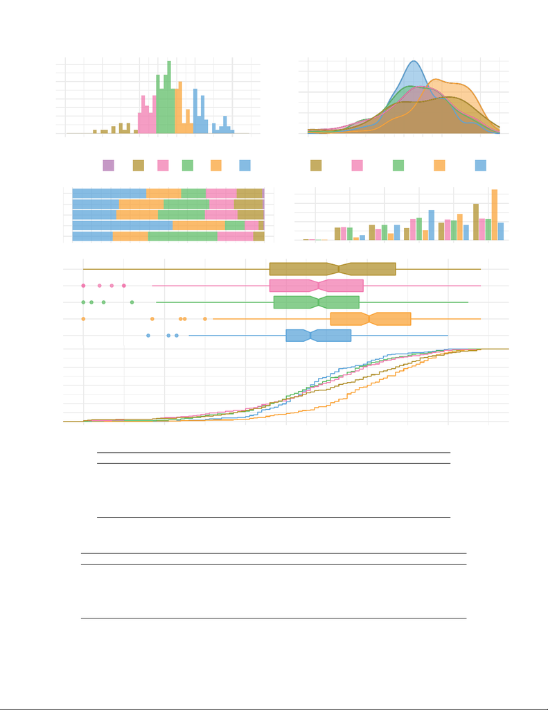

MA212: Further Mathematical Methods

2020/21

0 20 40 50 60 70 90

0

5

10

15

20

mark

count

0.0%

1.0%

2.0%

3.0%

0 20 40 50 60 70 90

mark

density

2020/21

2019/20

2018/19

2017/18

2016/17

0% 10% 20% 30% 40% 50% 60% 70% 80% 90% 100%

percent

Grades

AB F 3 2B 2A 1

0

50

100

AB F 3 2B 2A 1

grade

count

Year

2016/17 2017/18 2018/19 2019/20 2020/21

2020/21

2019/20

2018/19

2017/18

2016/17

0%

25%

50%

75%

100%

0 20 40 50 60 70 90

mark

Year results mean sd min q10 q25 median q75 q90 q95 max

2016/17 258 60.80 21.31 0 34 46 63.00 77 85 90 98

2017/18 240 56.70 19.33 0 29 46 58.00 69 81 86 98

2018/19 249 56.80 17.30 0 33 47 58.00 68 79 85 95

2019/20 262 69.20 15.13 0 48 61 70.50 80 87 89 98

2020/21 224 57.40 13.40 16 43 50 56.00 66 74 80 90

MA212: Mark summary – Mean, Standard deviation and Quantiles.

Year results AB F 3 2B 2A 1 %: AB F 3 2B 2A 1

2016/17 258 3 34 42 33 47 99 1.2 13.2 16.3 12.8 18.2 38.4

2017/18 240 2 36 31 57 56 58 0.8 15.0 12.9 23.8 23.3 24.2

2018/19 249 1 34 42 61 54 57 0.4 13.7 16.9 24.5 21.7 22.9

2019/20 262 1 7 19 27 71 137 0.4 2.7 7.3 10.3 27.1 52.3

2020/21 224 13 42 81 41 47 5.8 18.8 36.2 18.3 21.0

MA212: Grade Summary – Count and Percentage distribution.

14

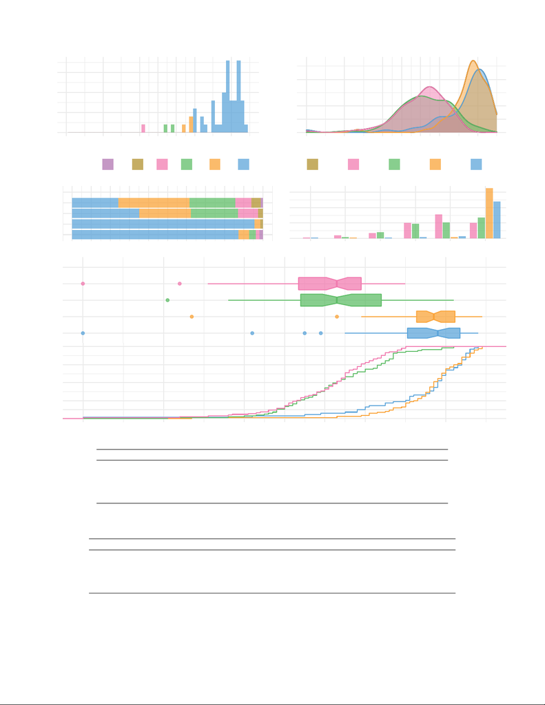

MA231: Operational Research Methods

2020/21

0 20 40 50 60 70 90

0.0

2.5

5.0

7.5

mark

count

0.0%

2.0%

4.0%

0 20 40 50 60 70 90

mark

density

2020/21

2019/20

2018/19

2017/18

2016/17

0% 10% 20% 30% 40% 50% 60% 70% 80% 90% 100%

percent

Grades

AB F 3 2B 2A 1

0

20

40

60

AB F 3 2B 2A 1

grade

count

Year

2016/17 2017/18 2018/19 2019/20 2020/21

2020/21

2019/20

2018/19

2017/18

2016/17

0%

25%

50%

75%

100%

0 20 40 50 60 70 90

mark

Year results mean sd min q10 q25 median q75 q90 q95 max

2017/18 83 60.50 13.42 0 46 53 63.00 69 75 78 80

2018/19 77 63.20 13.08 21 48 54 63.00 74 77 83 92

2019/20 68 85.90 10.57 27 75 82 87.00 92 96 97 99

2020/21 55 83.20 16.33 0 68 80 88.00 93 95 96 98

MA231: Mark summary – Mean, Standard deviation and Quantiles.

Year results AB F 3 2B 2A 1 %: AB F 3 2B 2A 1

2017/18 83 1 4 7 20 31 20 1.2 4.8 8.4 24.1 37.3 24.1

2018/19 77 2 8 19 21 27 2.6 10.4 24.7 27.3 35.1

2019/20 68 1 2 65 1.5 2.9 95.6

2020/21 55 1 1 2 3 48 1.8 1.8 3.6 5.5 87.3

MA231: Grade Summary – Count and Percentage distribution.

15

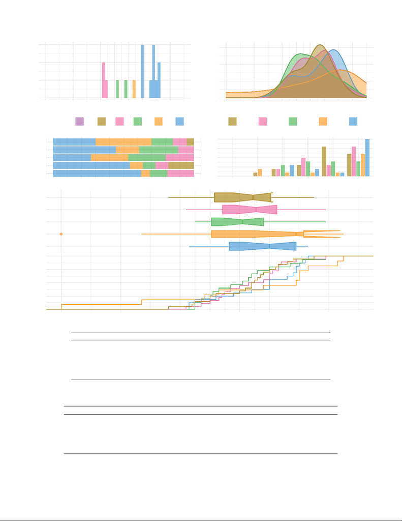

MA300: Game Theory

2020/21

0 20 40 50 60 70 90

0

1

2

3

mark

count

0.0%

1.0%

2.0%

3.0%

0 20 40 50 60 70 90

mark

density

2020/21

2019/20

2018/19

2017/18

2016/17

0% 10% 20% 30% 40% 50% 60% 70% 80% 90% 100%

percent

Grades

AB F 3 2B 2A 1

0.0

2.5

5.0

7.5

10.0

AB F 3 2B 2A 1

grade

count

Year

2016/17 2017/18 2018/19 2019/20 2020/21

2020/21

2019/20

2018/19

2017/18

2016/17

0%

25%

50%

75%

100%

0 20 40 50 60 70 90

mark

Year results mean sd min q10 q25 median q75 q90 q95 max

2016/17 20 62.40 12.65 36 44 51 64.50 70 76 78 85

2017/18 18 63.80 12.33 42 49 54 65.50 72 75 80 89

2018/19 15 61.30 13.54 45 45 50 61.00 68 79 83 89

2019/20 11 64.20 29.59 0 27 50 79.00 81 93 94 95

2020/21 16 67.00 14.42 43 44 56 70.00 79 81 82 83

MA300: Mark summary – Mean, Standard deviation and Quantiles.

Year results AB F 3 2B 2A 1 %: AB F 3 2B 2A 1

2016/17 20 1 2 3 8 6 5.0 10.0 15.0 40.0 30.0

2017/18 18 2 5 3 8 11.1 27.8 16.7 44.4

2018/19 15 3 4 4 4 20.0 26.7 26.7 26.7

2019/20 11 2 1 1 1 6 18.2 9.1 9.1 9.1 54.5

2020/21 16 3 2 1 10 18.8 12.5 6.2 62.5

MA300: Grade Summary – Count and Percentage distribution.

16

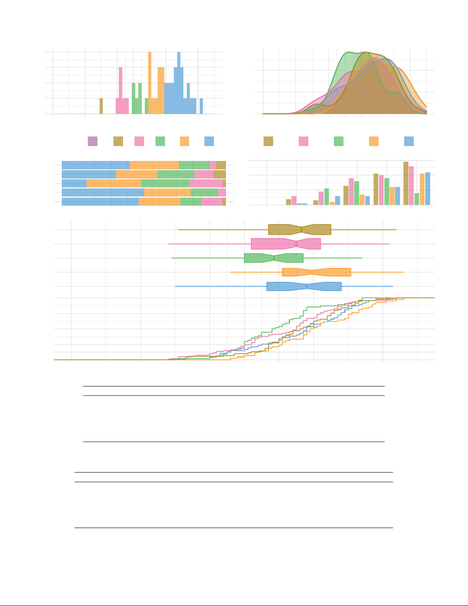

MA301: Game Theory I

2020/21

0 20 40 50 60 70 90

0

1

2

3

4

mark

count

0.0%

1.0%

2.0%

0 20 40 50 60 70 90

mark

density

2020/21

2019/20

2018/19

2017/18

2016/17

0% 10% 20% 30% 40% 50% 60% 70% 80% 90% 100%

percent

Grades

AB F 3 2B 2A 1

0

10

20

30

AB F 3 2B 2A 1

grade

count

Year

2016/17 2017/18 2018/19 2019/20 2020/21

2020/21

2019/20

2018/19

2017/18

2016/17

0%

25%

50%

75%

100%

0 20 40 50 60 70 90

mark

Year results mean sd min q10 q25 median q75 q90 q95 max

2016/17 70 65.70 13.38 31 50 57 66.50 75 82 83 94

2017/18 79 61.60 15.09 28 40 52 65.00 72 80 82 92

2018/19 54 59.20 12.40 29 45 50 58.50 67 78 82 84

2019/20 42 70.80 13.18 46 53 61 69.50 80 87 90 96

2020/21 47 66.40 14.79 30 44 56 68.00 78 83 85 93

MA301: Mark summary – Mean, Standard deviation and Quantiles.

Year results AB F 3 2B 2A 1 %: AB F 3 2B 2A 1

2016/17 70 4 3 13 21 29 5.7 4.3 18.6 30.0 41.4

2017/18 79 6 9 18 20 26 7.6 11.4 22.8 25.3 32.9

2018/19 54 1 11 16 18 8 1.9 20.4 29.6 33.3 14.8

2019/20 42 2 7 12 21 4.8 16.7 28.6 50.0

2020/21 47 1 6 6 12 22 2.1 12.8 12.8 25.5 46.8

MA301: Grade Summary – Count and Percentage distribution.

17

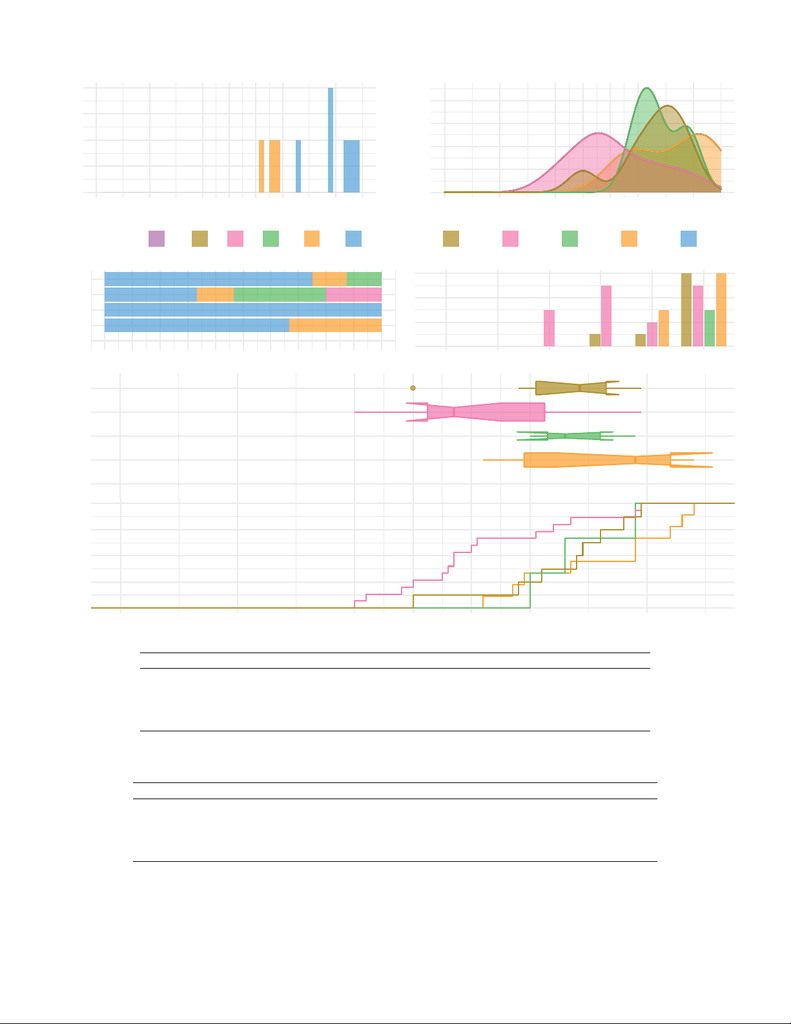

MA303: Chaos in Dynamical Systems

2019/20

0 20 40 50 60 70 90

0.0

0.5

1.0

1.5

2.0

mark

count

0.0%

1.0%

2.0%

3.0%

4.0%

0 20 40 50 60 70 90

mark

density

2020/21

2019/20

2018/19

2017/18

2016/17

0% 10% 20% 30% 40% 50% 60% 70% 80% 90% 100%

percent

Grades

AB F 3 2B 2A 1

0

2

4

6

AB F 3 2B 2A 1

grade

count

Year

2016/17 2017/18 2018/19 2019/20 2020/21

2020/21

2019/20

2018/19

2017/18

2016/17

0%

25%

50%

75%

100%

0 20 40 50 60 70 90

mark

Year results mean sd min q10 q25 median q75 q90 q95 max

2016/17 8 75.50 12.38 50 62 71 78.50 83 86 87 89

2017/18 15 61.70 15.16 40 44 52 57.00 72 83 88 89

2018/19 3 78.00 9.17 70 71 73 76.00 82 85 86 88

2019/20 9 82.10 13.63 62 66 69 88.00 94 96 97 98

MA303: Mark summary – Mean, Standard deviation and Quantiles.

Year results AB F 3 2B 2A 1 %: AB F 3 2B 2A 1

2016/17 8 1 1 6 12.5 12.5 75.0

2017/18 15 3 5 2 5 20.0 33.3 13.3 33.3

2018/19 3 3 100.0

2019/20 9 3 6 33.3 66.7

MA303: Grade Summary – Count and Percentage distribution.

18

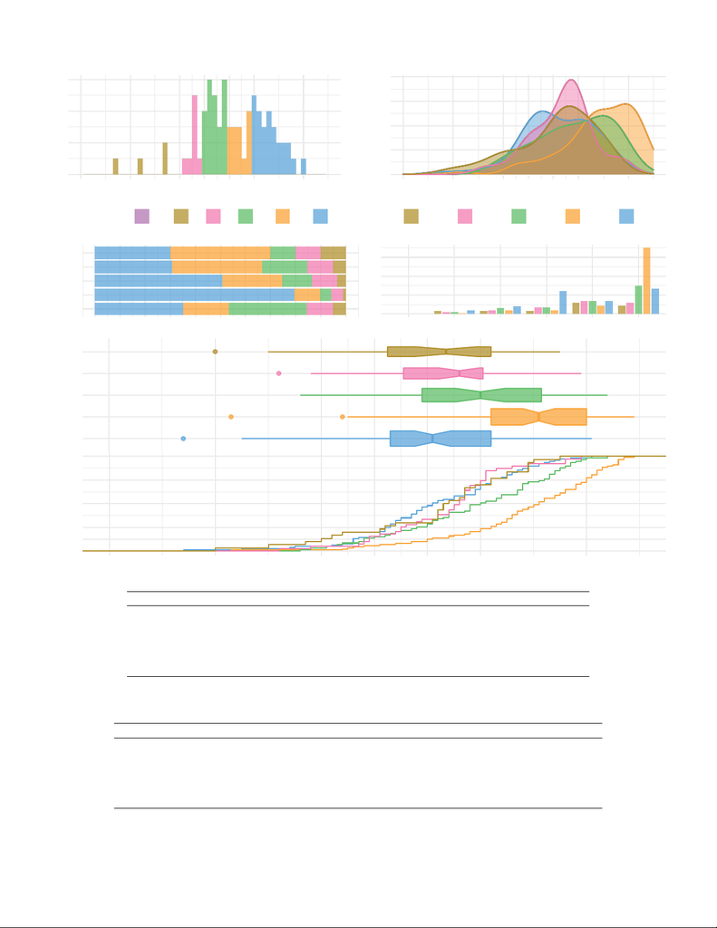

MA314: Algorithms and Programming

2020/21

0 20 40 50 60 70 90

0

2

4

6

mark

count

0.0%

1.0%

2.0%

3.0%

4.0%

0 20 40 50 60 70 90

mark

density

2020/21

2019/20

2018/19

2017/18

2016/17

0% 10% 20% 30% 40% 50% 60% 70% 80% 90% 100%

percent

Grades

AB F 3 2B 2A 1

0

20

40

60

AB F 3 2B 2A 1

grade

count

Year

2016/17 2017/18 2018/19 2019/20 2020/21

2020/21

2019/20

2018/19

2017/18

2016/17

0%

25%

50%

75%

100%

0 20 40 50 60 70 90

mark

Year results mean sd min q10 q25 median q75 q90 q95 max

2016/17 30 61.30 15.86 20 39 52 63.50 72 79 79 85

2017/18 39 63.60 12.19 32 48 55 66.00 70 76 86 89

2018/19 59 68.60 14.90 36 47 59 70.00 81 86 88 94

2019/20 88 78.60 14.65 23 59 72 81.00 90 94 96 99

2020/21 77 62.00 14.50 14 46 53 61.00 72 79 83 91

MA314: Mark summary – Mean, Standard deviation and Quantiles.

Year results AB F 3 2B 2A 1 %: AB F 3 2B 2A 1

2016/17 30 3 3 3 12 9 10.0 10.0 10.0 40.0 30.0

2017/18 39 2 4 7 14 12 5.1 10.3 17.9 35.9 30.8

2018/19 59 2 6 7 14 30 3.4 10.2 11.9 23.7 50.8

2019/20 88 1 4 4 9 70 1.1 4.5 4.5 10.2 79.5

2020/21 77 4 8 24 14 27 5.2 10.4 31.2 18.2 35.1

MA314: Grade Summary – Count and Percentage distribution.

19

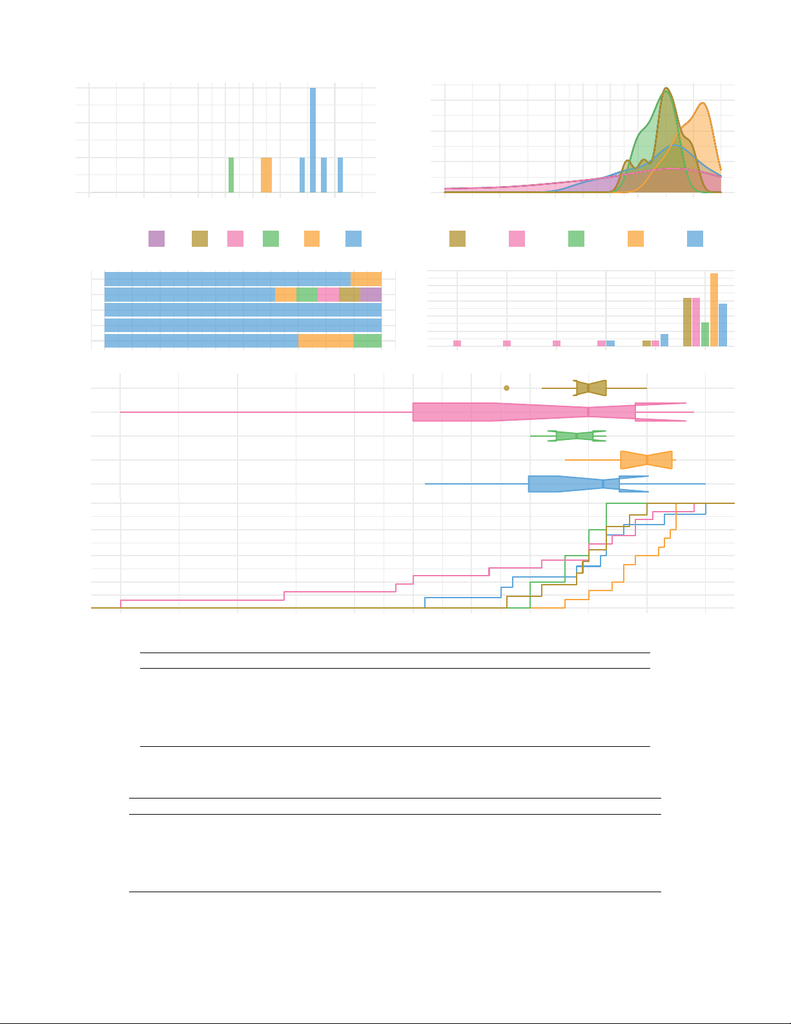

MA315: Algebra and its Applications

2020/21

0 20 40 50 60 70 90

0

1

2

3

mark

count

0.0%

2.0%

4.0%

6.0%

0 20 40 50 60 70 90

mark

density

2020/21

2019/20

2018/19

2017/18

2016/17

0% 10% 20% 30% 40% 50% 60% 70% 80% 90% 100%

percent

Grades

AB F 3 2B 2A 1

0.0

2.5

5.0

7.5

10.0

12.5

AB F 3 2B 2A 1

grade

count

Year

2016/17 2017/18 2018/19 2019/20 2020/21

2020/21

2019/20

2018/19

2017/18

2016/17

0%

25%

50%

75%

100%

0 20 40 50 60 70 90

mark

Year results mean sd min q10 q25 median q75 q90 q95 max

2016/17 9 79.80 7.34 66 70 78 80.00 83 87 88 90

2017/18 13 66.80 28.56 0 31 50 80.00 88 90 93 98

2018/19 4 77.20 5.62 70 71 74 78.00 80 82 82 83

2019/20 12 88.70 6.40 76 80 85 90.00 94 95 95 95

2020/21 10 78.90 14.13 52 63 69 82.50 85 93 96 100

MA315: Mark summary – Mean, Standard deviation and Quantiles.

Year results AB F 3 2B 2A 1 %: AB F 3 2B 2A 1

2016/17 9 1 8 11.1 88.9

2017/18 13 1 1 1 1 1 8 7.7 7.7 7.7 7.7 7.7 61.5

2018/19 4 4 100.0

2019/20 12 12 100.0

2020/21 10 1 2 7 10.0 20.0 70.0

MA315: Grade Summary – Count and Percentage distribution.

20

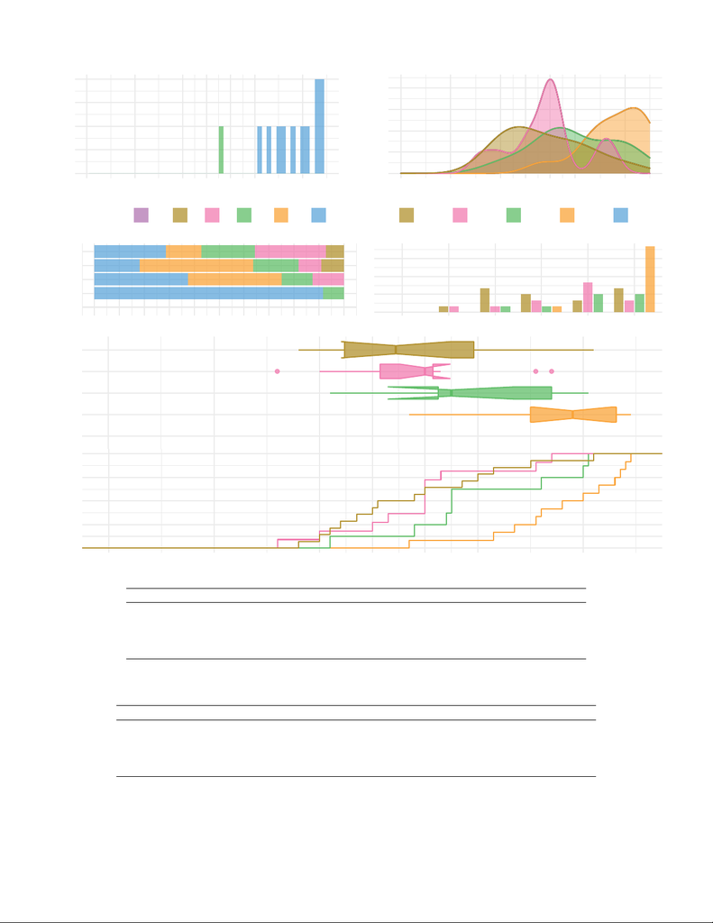

MA316: Graph Theory

2019/20

0 20 40 50 60 70 90

0.0

0.5

1.0

1.5

2.0

mark

count

0.0%

1.0%

2.0%

3.0%

4.0%

0 20 40 50 60 70 90

mark

density

2020/21

2019/20

2018/19

2017/18

2016/17

0% 10% 20% 30% 40% 50% 60% 70% 80% 90% 100%

percent

Grades

AB F 3 2B 2A 1

0

3

6

9

AB F 3 2B 2A 1

grade

count

Year

2016/17 2017/18 2018/19 2019/20 2020/21

2020/21

2019/20

2018/19

2017/18

2016/17

0%

25%

50%

75%

100%

0 20 40 50 60 70 90

mark

Year results mean sd min q10 q25 median q75 q90 q95 max

2016/17 14 57.90 16.61 36 40 44 54.50 69 77 84 92

2017/18 11 58.50 15.27 32 40 51 60.00 61 81 82 84

2018/19 8 69.60 16.89 42 53 62 65.00 84 90 90 91

2019/20 12 85.80 12.54 57 73 80 88.00 96 97 98 99

MA316: Mark summary – Mean, Standard deviation and Quantiles.

Year results AB F 3 2B 2A 1 %: AB F 3 2B 2A 1

2016/17 14 1 4 3 2 4 7.1 28.6 21.4 14.3 28.6

2017/18 11 1 1 2 5 2 9.1 9.1 18.2 45.5 18.2

2018/19 8 1 1 3 3 12.5 12.5 37.5 37.5

2019/20 12 1 11 8.3 91.7

MA316: Grade Summary – Count and Percentage distribution.

21

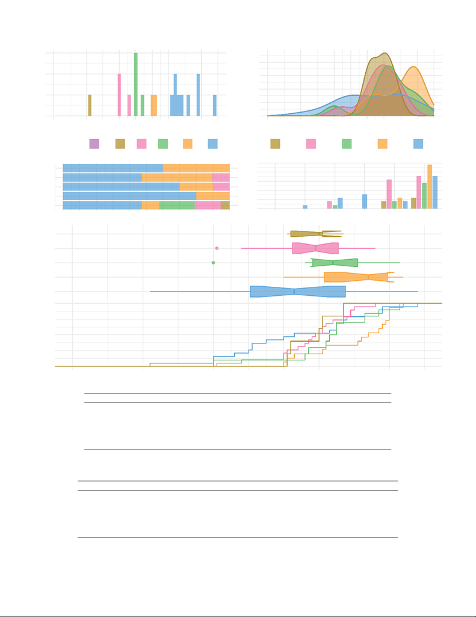

MA317: Complex Analysis

2020/21

0 20 40 50 60 70 90

0

1

2

3

mark

count

0.0%

1.0%

2.0%

3.0%

4.0%

0 20 40 50 60 70 90

mark

density

2020/21

2019/20

2018/19

2017/18

2016/17

0% 10% 20% 30% 40% 50% 60% 70% 80% 90% 100%

percent

Grades

AB F 3 2B 2A 1

0.0

2.5

5.0

7.5

10.0

12.5

AB F 3 2B 2A 1

grade

count

Year

2016/17 2017/18 2018/19 2019/20 2020/21

2020/21

2019/20

2018/19

2017/18

2016/17

0%

25%

50%

75%

100%

0 20 40 50 60 70 90

mark

Year results mean sd min q10 q25 median q75 q90 q95 max

2016/17 5 68.20 6.69 61 61 62 70.00 71 74 75 77

2017/18 19 68.10 11.03 41 57 62 69.00 75 79 80 86

2018/19 10 73.10 14.45 40 63 68 74.00 81 87 90 93

2019/20 15 80.10 11.67 60 61 71 84.00 89 90 91 94

2020/21 19 63.80 20.04 22 40 50 63.00 77 88 88 98

MA317: Mark summary – Mean, Standard deviation and Quantiles.

Year results AB F 3 2B 2A 1 %: AB F 3 2B 2A 1

2016/17 5 2 3 40.0 60.0

2017/18 19 2 8 9 10.5 42.1 47.4

2018/19 10 1 2 7 10.0 20.0 70.0

2019/20 15 3 12 20.0 80.0

2020/21 19 1 3 4 2 9 5.3 15.8 21.1 10.5 47.4

MA317: Grade Summary – Count and Percentage distribution.

22

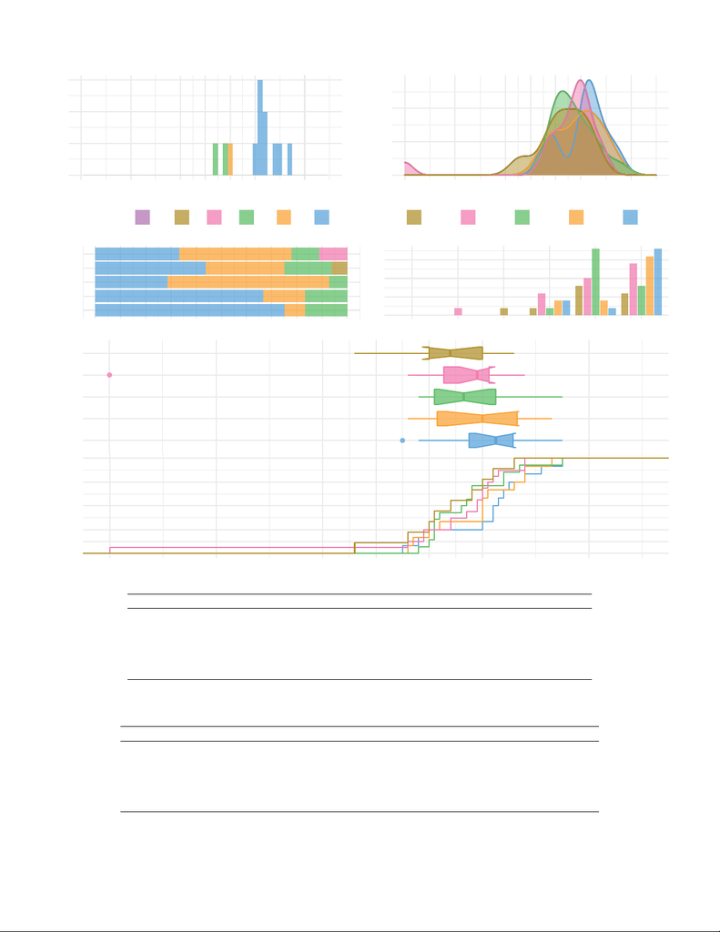

MA318: History of Mathematics in Finance and Economics

2020/21

0 20 40 50 60 70 90

0

1

2

3

mark

count

0.0%

2.0%

4.0%

0 20 40 50 60 70 90

mark

density

2020/21

2019/20

2018/19

2017/18

2016/17

0% 10% 20% 30% 40% 50% 60% 70% 80% 90% 100%

percent

Grades

AB F 3 2B 2A 1

0.0

2.5

5.0

7.5

AB F 3 2B 2A 1

grade

count

Year

2016/17 2017/18 2018/19 2019/20 2020/21

2020/21

2019/20

2018/19

2017/18

2016/17

0%

25%

50%

75%

100%

0 20 40 50 60 70 90

mark

Year results mean sd min q10 q25 median q75 q90 q95 max

2016/17 9 63.70 9.17 46 54 60 64.00 70 72 74 76

2017/18 16 63.70 18.12 0 57 62 69.00 71 75 78 78

2018/19 14 67.30 7.78 58 60 61 66.50 72 76 79 85

2019/20 12 69.20 8.82 56 57 61 70.00 76 78 80 83

2020/21 12 71.10 9.16 55 58 67 72.50 75 80 82 85

MA318: Mark summary – Mean, Standard deviation and Quantiles.

Year results AB F 3 2B 2A 1 %: AB F 3 2B 2A 1

2016/17 9 1 1 4 3 11.1 11.1 44.4 33.3

2017/18 16 1 3 5 7 6.2 18.8 31.2 43.8

2018/19 14 1 9 4 7.1 64.3 28.6

2019/20 12 2 2 8 16.7 16.7 66.7

2020/21 12 2 1 9 16.7 8.3 75.0

MA318: Grade Summary – Count and Percentage distribution.

23

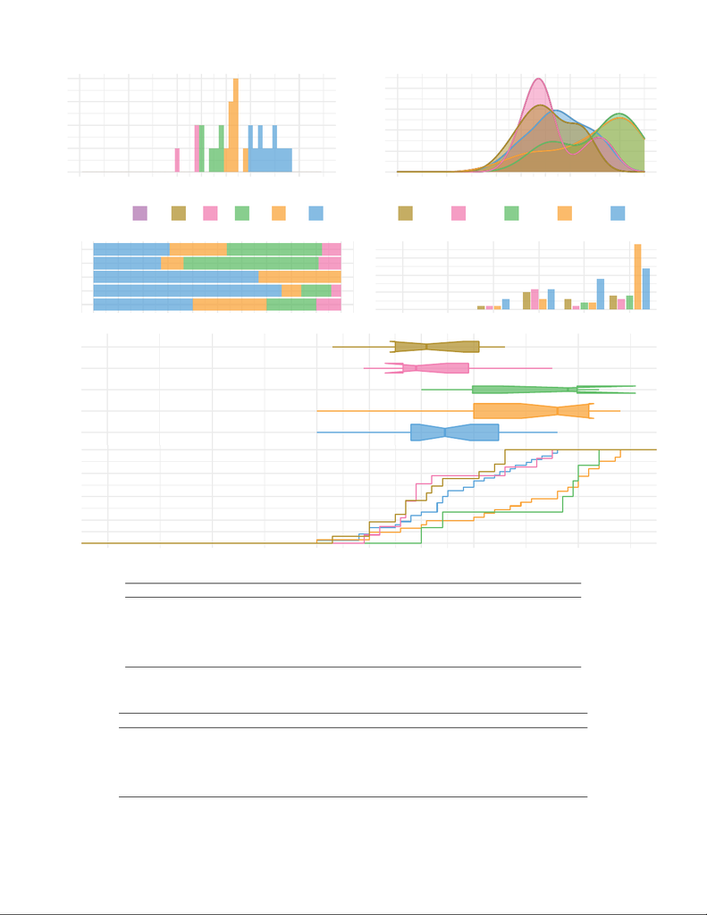

MA319: Partial Differential Equations

2020/21

0 20 40 50 60 70 90

0

1

2

3

4

mark

count

0.0%

1.0%

2.0%

3.0%

4.0%

0 20 40 50 60 70 90

mark

density

2020/21

2019/20

2018/19

2017/18

2016/17

0% 10% 20% 30% 40% 50% 60% 70% 80% 90% 100%

percent

Grades

AB F 3 2B 2A 1

0

5

10

15

AB F 3 2B 2A 1

grade

count

Year

2016/17 2017/18 2018/19 2019/20 2020/21

2020/21

2019/20

2018/19

2017/18

2016/17

0%

25%

50%

75%

100%

0 20 40 50 60 70 90

mark

Year results mean sd min q10 q25 median q75 q90 q95 max

2016/17 13 61.20 10.65 43 50 55 61.00 71 75 76 76

2017/18 11 63.10 12.19 49 52 56 59.00 69 82 83 85

2018/19 6 80.70 14.69 60 62 69 88.00 89 92 93 94

2019/20 25 78.60 17.02 40 52 70 86.00 92 95 97 98

2020/21 30 65.60 12.04 40 49 58 64.50 74 81 84 86

MA319: Mark summary – Mean, Standard deviation and Quantiles.

Year results AB F 3 2B 2A 1 %: AB F 3 2B 2A 1

2016/17 13 1 5 3 4 7.7 38.5 23.1 30.8

2017/18 11 1 6 1 3 9.1 54.5 9.1 27.3

2018/19 6 2 4 33.3 66.7

2019/20 25 1 3 2 19 4.0 12.0 8.0 76.0

2020/21 30 3 6 9 12 10.0 20.0 30.0 40.0

MA319: Grade Summary – Count and Percentage distribution.

24

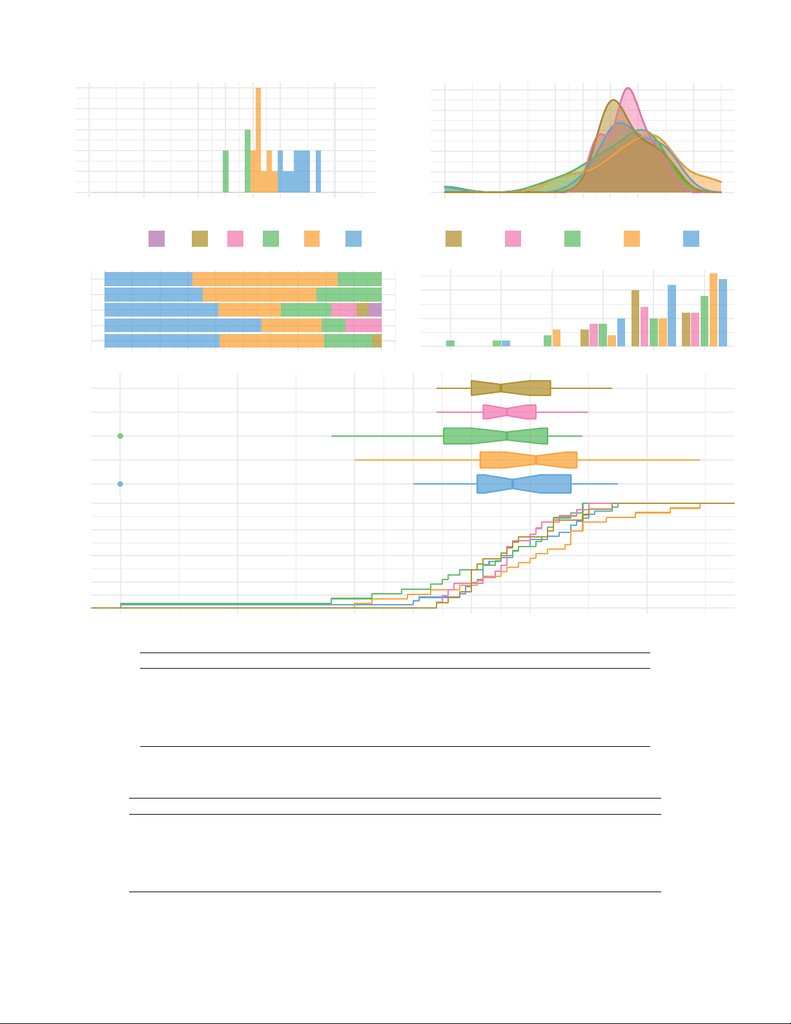

MA320: Mathematics of Networks

2020/21

0 20 40 50 60 70 90

0

1

2

3

4

5

mark

count

0.0%

1.0%

2.0%

3.0%

4.0%

5.0%

0 20 40 50 60 70 90

mark

density

2020/21

2019/20

2018/19

2017/18

2016/17

0% 10% 20% 30% 40% 50% 60% 70% 80% 90% 100%

percent

Grades

AB F 3 2B 2A 1

0

5

10

AB F 3 2B 2A 1

grade

count

Year

2016/17 2017/18 2018/19 2019/20 2020/21

2020/21

2019/20

2018/19

2017/18

2016/17

0%

25%

50%

75%

100%

0 20 40 50 60 70 90

mark

Year results mean sd min q10 q25 median q75 q90 q95 max

2016/17 19 66.40 8.70 54 57 60 65.00 73 79 80 84

2017/18 17 66.10 7.77 54 55 62 66.00 71 76 78 80

2018/19 22 61.20 18.04 0 43 55 66.00 73 76 78 79

2019/20 23 69.90 15.01 40 49 61 71.00 78 87 93 99

2020/21 29 65.70 15.77 0 56 61 67.00 77 80 82 85

MA320: Mark summary – Mean, Standard deviation and Quantiles.

Year results AB F 3 2B 2A 1 %: AB F 3 2B 2A 1

2016/17 19 3 10 6 15.8 52.6 31.6

2017/18 17 4 7 6 23.5 41.2 35.3

2018/19 22 1 1 2 4 5 9 4.5 4.5 9.1 18.2 22.7 40.9

2019/20 23 3 2 5 13 13.0 8.7 21.7 56.5

2020/21 29 1 5 11 12 3.4 17.2 37.9 41.4

MA320: Grade Summary – Count and Percentage distribution.

25

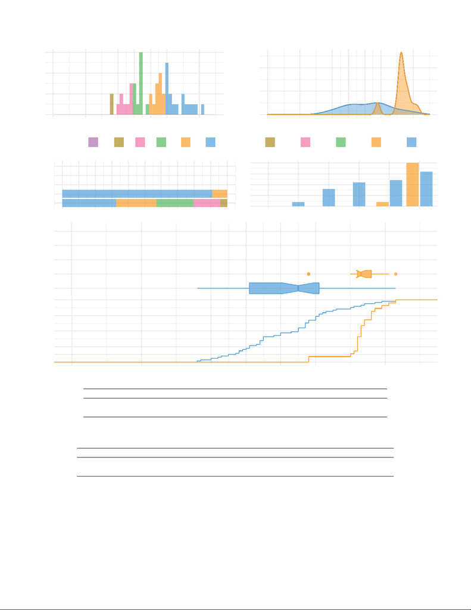

MA321: Measure Theoretic Probability

2020/21

0 20 40 50 60 70 90

0

2

4

6

mark

count

0.0%

5.0%

10.0%

0 20 40 50 60 70 90

mark

density

2020/21

2019/20

2018/19

2017/18

2016/17

0% 10% 20% 30% 40% 50% 60% 70% 80% 90% 100%

percent

Grades

AB F 3 2B 2A 1

0

5

10

15

20

AB F 3 2B 2A 1

grade

count

Year

2016/17 2017/18 2018/19 2019/20 2020/21

2020/21

2019/20

2018/19

2017/18

2016/17

0%

25%

50%

75%

100%

0 20 40 50 60 70 90

mark

Year results mean sd min q10 q25 median q75 q90 q95 max

2019/20 22 83.00 5.83 68 80 82 83.00 86 88 90 93

2020/21 49 62.30 14.08 36 44 51 65.00 71 81 85 93

MA321: Mark summary – Mean, Standard deviation and Quantiles.

Year results AB F 3 2B 2A 1 %: AB F 3 2B 2A 1

2019/20 22 2 20 9.1 90.9

2020/21 49 2 8 11 12 16 4.1 16.3 22.4 24.5 32.7

MA321: Grade Summary – Count and Percentage distribution.

26

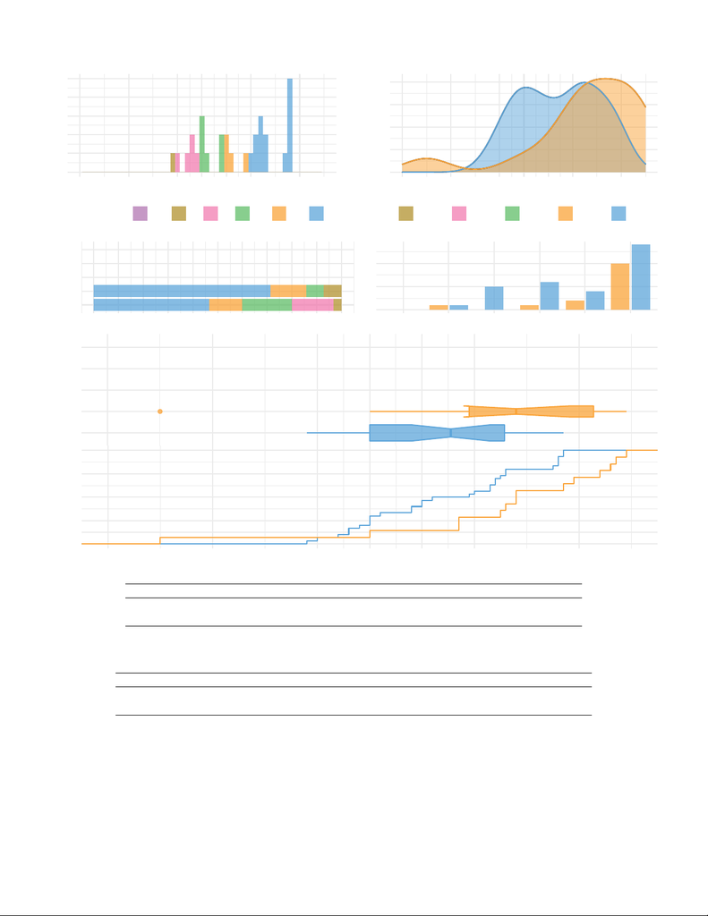

MA322: Mathematics of Finance and Valuation

2020/21

0 20 40 50 60 70 90

0

1

2

3

4

5

mark

count

0.00%

0.50%

1.00%

1.50%

2.00%

0 20 40 50 60 70 90

mark

density

2020/21

2019/20

2018/19

2017/18

2016/17

0% 10% 20% 30% 40% 50% 60% 70% 80% 90% 100%

percent

Grades

AB F 3 2B 2A 1

0

5

10

AB F 3 2B 2A 1

grade

count

Year

2016/17 2017/18 2018/19 2019/20 2020/21

2020/21

2019/20

2018/19

2017/18

2016/17

0%

25%

50%

75%

100%

0 20 40 50 60 70 90

mark

Year results mean sd min q10 q25 median q75 q90 q95 max

2019/20 14 75.90 23.51 10 55 69 78.00 92 96 97 99

2020/21 30 64.60 15.72 38 45 50 65.50 75 86 86 87

MA322: Mark summary – Mean, Standard deviation and Quantiles.

Year results AB F 3 2B 2A 1 %: AB F 3 2B 2A 1

2019/20 14 1 1 2 10 7.1 7.1 14.3 71.4

2020/21 30 1 5 6 4 14 3.3 16.7 20.0 13.3 46.7

MA322: Grade Summary – Count and Percentage distribution.

27

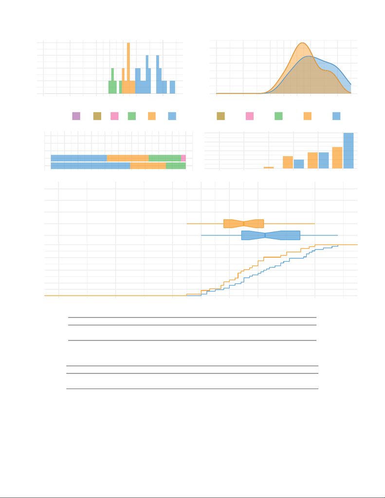

MA323: Computational Methods in Financial Mathematics

2020/21

0 20 40 50 60 70 90

0

1

2

3

4

mark

count

0.0%

1.0%

2.0%

3.0%

0 20 40 50 60 70 90

mark

density

2020/21

2019/20

2018/19

2017/18

2016/17

0% 10% 20% 30% 40% 50% 60% 70% 80% 90% 100%

percent

Grades

AB F 3 2B 2A 1

0

5

10

15

20

AB F 3 2B 2A 1

grade

count

Year

2016/17 2017/18 2018/19 2019/20 2020/21

2020/21

2019/20

2018/19

2017/18

2016/17

0%

25%

50%

75%

100%

0 20 40 50 60 70 90

mark

Year results mean sd min q10 q25 median q75 q90 q95 max

2019/20 29 67.00 11.82 45 52 58 65.00 72 85 86 90

2020/21 34 73.20 13.34 50 55 64 72.50 84 89 94 98

MA323: Mark summary – Mean, Standard deviation and Quantiles.

Year results AB F 3 2B 2A 1 %: AB F 3 2B 2A 1

2019/20 29 1 7 9 12 3.4 24.1 31.0 41.4

2020/21 34 5 9 20 14.7 26.5 58.8

MA323: Grade Summary – Count and Percentage distribution.

28

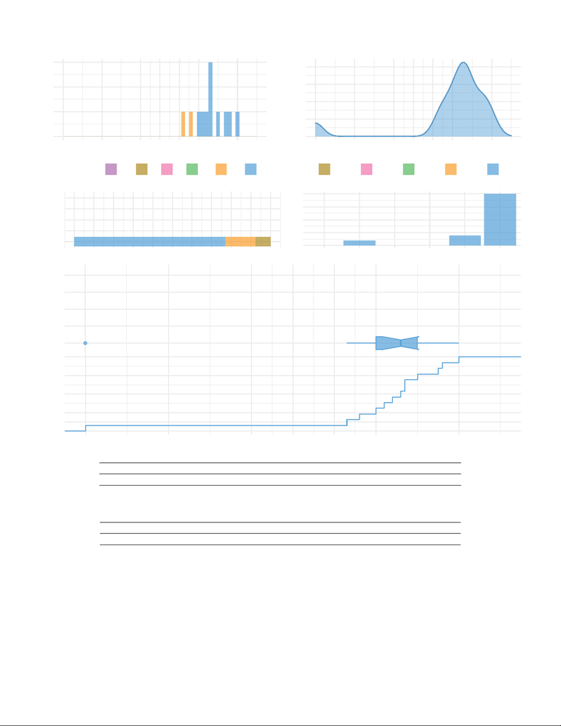

MA334: Dissertation in Mathematics

2020/21

0 20 40 50 60 70 90

0

1

2

3

mark

count

0.0%

1.0%

2.0%

3.0%

4.0%

0 20 40 50 60 70 90

mark

density

2020/21

2019/20

2018/19

2017/18

2016/17

0% 10% 20% 30% 40% 50% 60% 70% 80% 90% 100%

percent

Grades

AB F 3 2B 2A 1

0.0

2.5

5.0

7.5

10.0

AB F 3 2B 2A 1

grade

count

Year

2016/17 2017/18 2018/19 2019/20 2020/21

2020/21

2019/20

2018/19

2017/18

2016/17

0%

25%

50%

75%

100%

0 20 40 50 60 70 90

mark

Year results mean sd min q10 q25 median q75 q90 q95 max

2020/21 13 70.50 22.54 0 63 70 76.00 80 85 87 90

MA334: Mark summary – Mean, Standard deviation and Quantiles.

Year results AB F 3 2B 2A 1 %: AB F 3 2B 2A 1

2020/21 13 1 2 10 7.7 15.4 76.9

MA334: Grade Summary – Count and Percentage distribution.

29